# Homework 9

Liu Huihang

10/30/2019

## Problem 1 (HW 9.1)

For the data set **faithful** in R, use the normal mixed model to estimate the joint density function of **eruptions** and **waiting**, write your EM algorithm, and compare it with the **normalmixEM** function in the **mixtools** package.

## Problem 2 (HW 9.2)

Write a density estimation function using **knn.dist** function in the **FNN** package, and perform k-nearest neighbor density estimation on the data in Problem 1.

## Answer 1

Let’s have a insight of the faithful data,

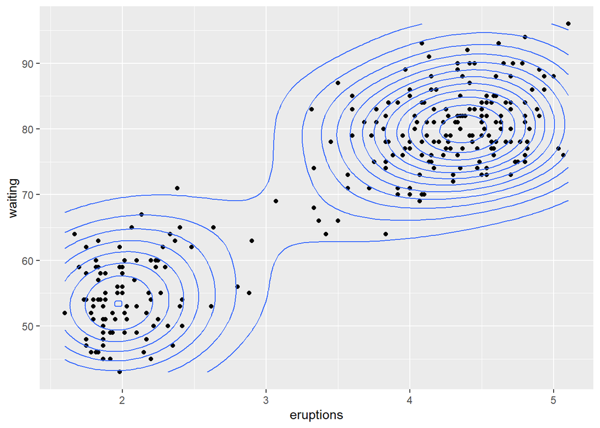

```r
data("faithful")
ggplot(faithful, aes(x = eruptions, y = waiting)) + geom_point() + stat_density2d()
```

This is a Gaussian mixture of $K$ components,
$$\begin{equation}
p(x|\Psi) = \sum_{k=1}^{K} \pi_k \phi(x|\mu_k, \sigma_k),
\end{equation}$$
the parameters
$$\begin{equation}
\Psi = \left\{ (\pi_1, \mu_1, \Sigma_1),\dots (\pi_K, \mu_K, \Sigma_K) \right\}
\end{equation}$$
The complete likelihood function becomes
$$\begin{equation}
L(\Psi) = \prod_{i=1}^n \prod_{k=1}^K \left[ \pi_k\cdot \phi(x_i| \mu_k,\Sigma_k)\right]^{z_k}
\end{equation}$$
and the complete log-likelihood function becomes
$$\begin{equation}
\begin{split}
ln(L)
& = \sum_{i=1}^n \sum_{k=1}^K z_k \left[ ln(\pi_k) + ln\phi(x_i| \mu_k,\Sigma_k)\right] \\
& = \sum_{i=1}^n \sum_{k=1}^K z_k \left[ ln(\pi_k) + C - \frac{1}{2}ln|\Sigma_k| - \frac{1}{2} tr\left[ \Sigma_k^{-1} (x_i -\mu_k)(x_i -\mu_k)^T \right] \right] \\
& \propto \sum_{i=1}^n \sum_{k=1}^K z_k \left[ ln(\pi_k) - \frac{1}{2}ln|\Sigma_k| - \frac{1}{2} tr\left[ \Sigma_k^{-1} (x_i -\mu_k)(x_i -\mu_k)^T \right] \right] \\
\end{split}
\end{equation}$$

- E Step

$$\begin{equation}
\hat{z}_{ik} = \frac{\pi_k \phi(x_i | \mu_k, \sigma_k)}{\sum_{m=1}^2 \pi_m \phi(x_i | \mu_m, \sigma_m)}
\end{equation}$$

- M Step

$$\begin{equation}
\begin{split}
\hat{\pi}_k^{new} & = \frac{\sum_{i=1}^n \hat{z}_{ik}}{n} \\
\hat{\mu}_k^{new} & = \frac{\sum_{i=1}^n \hat{z}_{ik}x_i}{\sum_{i=1}^n \hat{z}_{ik}} \\
\hat{\Sigma}_k^{new} & = \frac{\sum_{i=1}^n \hat{z}_{ik} (x_i-\hat{\mu}_k)^T(x_i-\hat{\mu}_k)}{\sum_{i=1}^n \hat{z}_{ik}} \\
\end{split}
\end{equation}$$

The algrithem is initialized randomly.

```r
# load data
library("mvtnorm") # multi-normal density function
data("faithful")
head(faithful, 5)
```

```
##   eruptions waiting
## 1     3.600      79
## 2     1.800      54
## 3     3.333      74
## 4     2.283      62
## 5     4.533      85
```

```r
x <- data.matrix(faithful)

# initialization
set.seed(111)
n <- 272
K <- 2
Dim <- 2
eps <- 1e-4
Pi <- c(0.5, 0.5)
mu <- rep(0, Dim*K); dim(mu) <- c(Dim, K)
Sig <- rep(0, Dim*Dim*K); dim(Sig) <- c(Dim, Dim, K)

mu_tmp <- matrix(c(2,55, 4.5, 80), 2, 2)
for (k in 1:K) {
  Sig[,,k] <- t(x-t(colMeans(x)%*%t(matrix(rep(1, n), nrow=n))))%*%(x-t(colMeans(x)%*%t(matrix(rep(1, n), nrow=n))))/n + diag(abs(rnorm(2)))*5 # t(scale(x, center=TRUE, scale=FALSE))%*%scale(x, center=TRUE, scale=FALSE)
  mu[,k] <- mu_tmp[, k] # colMeans(x) + rnorm(2)*5
}

# EM Algorithm
e_step <- function(Pi, mu, Sig){
  zz <- rep(0, n*K); dim(zz) <- c(n, K)
  for (ii in 1:n) {
    for (k in 1:K) {
      zz[ii, k] <- Pi[k]*dmvnorm(x[ii,], mean=mu[,k], sigma=Sig[,,k])
    }
    tmp <- sum(zz[ii,])
    for (k in 1:K) {
      zz[ii, k] <- zz[ii, k] / tmp
    }
  }
  return(zz)
}

m_step <- function(zz){
  Pi <- colMeans(zz)
  for (k in 1:K) {
    mu[,k] <- colSums(matrix(unlist(lapply(1:n, function(ii) zz[ii,k] * x[ii,])), nrow=n, byrow=TRUE)) / colSums(zz)[k]
    Sig[,,k] <- matrix(colSums(matrix(unlist(lapply(1:n, function(ii) zz[ii,k] * t(t(x[ii,]-mu[,k]))%*%t(x[ii,]-mu[,k]) )), nrow=n, byrow=TRUE)), nrow=Dim) / colSums(zz)[k]
  }
  return(list(Pi, mu, Sig))
}

iter_num <- 0
while (TRUE) {
  z <- e_step(Pi, mu, Sig)
  re <- m_step(z)
  Pi_new <- re[[1]]; mu_new <- re[[2]]; Sig_new <- re[[3]]
  if (norm(matrix(Pi_new-Pi))<eps & norm(mu-mu_new)<eps & norm(Sig[,,1]-Sig_new[,,1])<eps & norm(Sig[,,2]-Sig_new[,,2])<eps) break
  Pi <- Pi_new; mu <- mu_new; Sig <- Sig_new
  iter_num <- iter_num + 1
}
cat("number of iterations = ", iter_num, "\n")
```

```
## number of iterations =  13
```

```r
print(Pi)
```

```
## [1] 0.3558731 0.6441269
```

```r
print(mu)
```

```
##           [,1]      [,2]
## [1,]  2.036389  4.289663
## [2,] 54.478523 79.968123
```

```r
print(Sig)
```

```
## , , 1
##
##            [,1]       [,2]
## [1,] 0.06916823  0.4351735
## [2,] 0.43517346 33.6973219
##
## , , 2
##
##           [,1]       [,2]
## [1,] 0.1699676  0.9405992
## [2,] 0.9405992 36.0460979
```

The results show that the algorithm iterates 13 times and then converges. It has two compoents and their ratio is $\pi=(0.3558731, 0.6441269)$, each binary normal distribution has $\mu, \Sigma$ as shown above.

Now, let’s take a look at the results from **mixtools** package. The **mvnormalmixEM** function returns EM algorithm output for mixtures of multivariate normal distributions. We can use its default parameters and get the following result.

```r
library("mixtools")
```

Because this problem is a binary normal distribution, we use **mvnormalmixEM** rather than **normalmixEM**. It is very simple to use the result is shown in the following.

```r
result.EM = mvnormalmixEM(x, k=2)
```

```
## number of iterations= 14
```

```r
print(result.EM$lambda)
```

```
## [1] 0.3558729 0.6441271
```

```r
print(result.EM$mu)
```

```
## [[1]]
## [1]  2.036389 54.478517
##
## [[2]]
## [1]  4.289662 79.968116
```

```r
print(result.EM$sigma)
```

```
## [[1]]
##            [,1]       [,2]
## [1,] 0.06916774  0.4351683
## [2,] 0.43516834 33.6972870
##
## [[2]]
##           [,1]       [,2]
## [1,] 0.1699683  0.9406081
## [2,] 0.9406081 36.0461974
```

We can conclude that, my EM algorithm performs as well as **mixtools** package because they return the same parameters $\pi_k,\mu_k,\Sigma_k$.

Method

$\pi$

$\mu$

$\Sigma$

My EM Alg.

- $0.3559$
- $0.6441$
- $(2.0363,54.478)$
- $(4.2896,79.968)$
- $\begin{pmatrix} 0.06917 & 0.4352\\ 0.4352 & 33.697 \end{pmatrix}$
- $\begin{pmatrix} 0.1700 & 0.9406\\ 0.9406 & 36.046 \end{pmatrix}$

mixtools

- $0.3559$
- $0.6441$
- $(2.0363,54.479)$
- $(4.2897,79.968)$
- $\begin{pmatrix} 0.06917 & 0.4352\\ 0.4352 & 33.697 \end{pmatrix}$
- $\begin{pmatrix} 0.1700 & 0.9406\\ 0.9406 & 36.046 \end{pmatrix}$

But we should notice that the EM algorithm is sensitive to initial values of parameters, if we choose parameters randomly, the algorithm may not converge that quickly.

## Answer 2

**knn.dist** function in **FNN* package is a fast k-nearest neighbor distance searching algorithms returns the Euclidiean distances of k nearest neighbors. And we have** knnx.dist** and **knnx.index** to evulate knn at input $x$ and return neighbours’ indexes and distances.

The algorithm is very simple, we just need to do some simple calculate to evaluate $\hat{f}(x)$ at some different position.
$$\begin{equation}
\hat{f}(x) = \frac{1}{n} \sum_{i=1}^n \frac{1}{2d_k(x)} I(|x-X_i|\le d_k(x))
\end{equation}$$

I take $k=10$ emperically.

```r
library("FNN")
library("parallel")

k <- 10
# kdist <- knn.dist(x, k=k)
f.knn <- function(t){
  # t <- matrix(c(yy, zz), nrow=1)
  h <- knnx.dist(data=x, query=t, k=k)[1,10]
  idx_t <- knnx.index(data=x, query=t, k=k)
  fhx <- 0
  for (ii in 1:dim(idx_t)[2]) {
    if (norm(x[idx_t[ii],] - t, "2") / h < 1)
      fhx <- fhx + 1 / h
  }
  fhx / (2*length(x))
}
yy <- seq(1, 5.5, length.out=20)
zz <- seq(40, 100, length.out=20)
f.hat <- matrix(rep(0, length(yy)*length(zz)), nrow=length(yy))
ex <- function(ii){
  unlist(lapply(1:length(zz), function(jj, y) {
                                      tt <- matrix(c(y, zz[jj]), nrow=1)
                                      return(f.knn(tt))
                            }, yy[ii]))
}
cl <- makeCluster(getOption("cl.cores", as.integer(detectCores()/2)))
clusterExport(cl, c('f.knn', 'x', 'yy', 'zz', 'k', 'knnx.dist', 'knnx.index'))                # include all the function needed
res <- parSapply(cl, 1:length(yy), ex)
stopCluster(cl)
```

We use **plotly** package to draw 3d surface of density function as following.

```r
# draw density  fucntion
library("plotly")
plot_ly() %>%
add_surface(z = ~res)
```

[interactive chart not shown]